# Introduction

## This project seeks to comment on the ethical issues that emerge due to AI and the use of the German Credit dataset to detect and minimise the bias in the AI systems. The process of credit risk assessment can be carried out in an automated manner that does not focus on or consider sensitive qualities such as sex and age, in which case the decision made would not be fair in the context of the credit. This report falls into a systematic approach, namely: Exploratory Data Analysis, Data Preprocessing, Fairness Baseline Model Development and Testing of Fairness, Fairness-Mitigation through a Fairness Awareness Algorithm. The outcomes must lead to fair forecasts, decision-making is made more transparent, and ethical, non-biased credit assessment recommendations are made.

# Problem Statement

## One of the most crucial activities in the financial sector is to establish whether a customer can be a creditworthy one when he/she requests a loan. The exercise is accomplished by using the German Credit data. Data may end up reaffirming prejudice against certain groups of people, particularly when it comes to gender or age, with a machine learning model. This can bring about an imbalance in credit decision-making, court proceedings and credit establishment losses to the financial institutions. The project aims to identify whether or not a certain prediction model of credit risk is biased, quantify the unfairness of the model on the protected attributes and construct a new solution to the biased model. The solutions would also assist in attracting a wider talent pool, adherence to regulations, and the use of AI in practice in a way that is ethically appropriate, such as lending.

# Dataset Description and Data Understanding

## The German Credit Risk dataset, where credit classification was centralised and where it sought to categorise an applicant as either a good or bad credit risk (Kaggle, 2026). The records refer to a specific applicant requesting a loan in a bank, and are classified into a group of financial and personal attributes. The initial information consisted of sophisticated data which had encoding through symbols, thus making it hard to analyse the data directly. Accordingly, it was converted into a readable format, CSV, using Python, removing some very pertinent columns. The dataset has been purified and now features a defined structure that can be easily used to assess its fairness as well as process it to be used in machine learning.

# Ethical Concerns

## Predicting credit risk with machine learning poses serious ethical problems, mainly relating to fairness and unfairness. The credit data of the German has certain sensitive features (sex, age) which are also likely to influence the model output, even resulting in a biased tendency to a certain group in any prediction. An example is women or younger applicants who may be assigned a negative rating of their creditworthiness despite having economic indicators similar to the remaining applicants (Genovesi et al., 2024). Legal and reputational issues with financial institutions could arise out of this, irrespective of the ethical issues involved. The original data is not balanced on how the different groups of demographics and categories are represented and when learned by models, the imbalance in representation of the various groups might be even increased. Predictive accuracy can be maximised using machine learning algorithms, but at the same time, that can uphold social and ethical concerns in large measure, and may enhance systemic inequities unless carefully evaluated on these aspects.

## Moreover, opaque classifiers like the Random Forest or ensemble may even be difficult to interpret since the answer may not be clear as to why a particular individual is said to be at high risk. Transparency in the context of fair and responsible use of AI systems can be core to regulatory compliance, which in the case of the United Kingdom, the GDPR outlines as fairness, accountability, and explainability to inform AI-driven processes of decision-making (Sargeant, 2026). These are some areas of ethical concerns which demand the prior processing of the information, modelling the information with considerations of fairness and keeping a close check on the outcomes of the model on sensitive populations. Mitigation methods should be fair, maintain the performance of the model and be simple enough to articulate by the stakeholders.

# Dataset Exploration (EDA)

# **Import Libraries**

```python
!pip install fairlearn
```

```python
import pandas as pd
import numpy as np
import matplotlib.pyplot as plt
import seaborn as sns
from sklearn.model_selection import train_test_split
from sklearn.preprocessing import LabelEncoder, OneHotEncoder
from sklearn.impute import SimpleImputer
from sklearn.ensemble import RandomForestClassifier
from sklearn.metrics import accuracy_score, confusion_matrix, classification_report
from fairlearn.metrics import MetricFrame, demographic_parity_difference, equalized_odds_difference
from fairlearn.reductions import ExponentiatedGradient, DemographicParity
```

## This figure suggests the initial configuration of the analysis, which would be the imports of the LIBRARies to process the data, visualisation, modelling and evaluation of fairness using machine learning. German_Credit is the name can give to DataFrame that can be created. Dataframe can be referred to as German_Credit since it is created and can be further processed and explored.

# **Load Dataset into DataFrame "German_Credit"**

```python
German_Credit = pd.read_csv("german_credit_data.csv")
```

# **Explore Dataset**

```python
German_Credit.head()
```

|  | Unnamed: 0 | Age | Sex | Job | Housing | Saving accounts | Checking account | Credit amount | Duration | Purpose |
| --- | --- | --- | --- | --- | --- | --- | --- | --- | --- | --- |
| 0 | 0 | 67 | male | 2 | own | NaN | little | 1169 | 6 | radio/TV |
| 1 | 1 | 22 | female | 2 | own | little | moderate | 5951 | 48 | radio/TV |
| 2 | 2 | 49 | male | 1 | own | little | NaN | 2096 | 12 | education |
| 3 | 3 | 45 | male | 2 | free | little | little | 7882 | 42 | furniture/equipment |
| 4 | 4 | 53 | male | 2 | free | little | little | 4870 | 24 | car |

```python
German_Credit.info()
```

```
<class 'pandas.core.frame.DataFrame'>
RangeIndex: 1000 entries, 0 to 999
Data columns (total 10 columns):
 #   Column            Non-Null Count  Dtype
---  ------            --------------  -----
 0   Unnamed: 0        1000 non-null   int64
 1   Age               1000 non-null   int64
 2   Sex               1000 non-null   object
 3   Job               1000 non-null   int64
 4   Housing           1000 non-null   object
 5   Saving accounts   817 non-null    object
 6   Checking account  606 non-null    object
 7   Credit amount     1000 non-null   int64
 8   Duration          1000 non-null   int64
 9   Purpose           1000 non-null   object
dtypes: int64(5), object(5)
memory usage: 78.3+ KB
```

## This can be the initial five rows of the data, as well as column information. It shows 1000 records, 10 columns, data type and null value by showing there are nulls that need to be pre-processed to the data type, Saving account as well as Checking account before training the model.

```python
German_Credit.describe()
```

|  | Unnamed: 0 | Age | Job | Credit amount | Duration |
| --- | --- | --- | --- | --- | --- |
| count | 1000.000000 | 1000.000000 | 1000.000000 | 1000.000000 | 1000.000000 |
| mean | 499.500000 | 35.546000 | 1.904000 | 3271.258000 | 20.903000 |
| std | 288.819436 | 11.375469 | 0.653614 | 2822.736876 | 12.058814 |
| min | 0.000000 | 19.000000 | 0.000000 | 250.000000 | 4.000000 |
| 25% | 249.750000 | 27.000000 | 2.000000 | 1365.500000 | 12.000000 |
| 50% | 499.500000 | 33.000000 | 2.000000 | 2319.500000 | 18.000000 |
| 75% | 749.250000 | 42.000000 | 2.000000 | 3972.250000 | 24.000000 |
| max | 999.000000 | 75.000000 | 3.000000 | 18424.000000 | 72.000000 |

## This number provides descriptive numeric data such as Age, Job, Credit amount and Duration. It indicates the range, means, standard deviations and quartiles which can indicate the presence of characteristics of the distribution, outliers and any discrepancies in the scale, all needed during preprocessing and/or fairness-conscious modelling.

# **Drop unnecessary columns**

```python
German_Credit.drop(columns=['Unnamed: 0'], inplace=True)  # Drop index column
```

# **Check number of missing values per column**

```python
# Check number of missing values per column
print("Missing values per column:")
print(German_Credit.isnull().sum())
```

```
Missing values per column:
Age                   0
Sex                   0
Job                   0
Housing               0
Saving accounts     183
Checking account    394
Credit amount         0
Duration              0
Purpose               0
dtype: int64
```

# **Handle missing values**

```python
imputer_saving = SimpleImputer(strategy='most_frequent')
German_Credit['Saving accounts'] = imputer_saving.fit_transform(German_Credit[['Saving accounts']]).ravel()

imputer_checking = SimpleImputer(strategy='most_frequent')
German_Credit['Checking account'] = imputer_checking.fit_transform(German_Credit[['Checking account']]).ravel()
```

### The interest that is lost due to unnecessary columns and missing values in "Saving account" (183) and "Checking account" (394) is shown here. The most common category value was used to fill missing data. This pre-processing technique leads to the fact that the data set can be complete without any data-related errors in making the model and preventing any bias by any missing data.

# **Age Distribution**

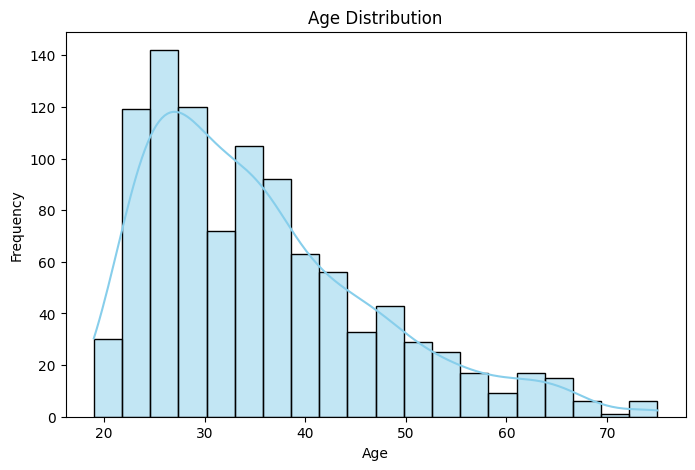

```python
plt.figure(figsize=(8,5))
sns.histplot(German_Credit['Age'], bins=20, kde=True, color='skyblue')
plt.title('Age Distribution')
plt.xlabel('Age')
plt.ylabel('Frequency')
plt.show()
```

# **Credit Amount Distribution**

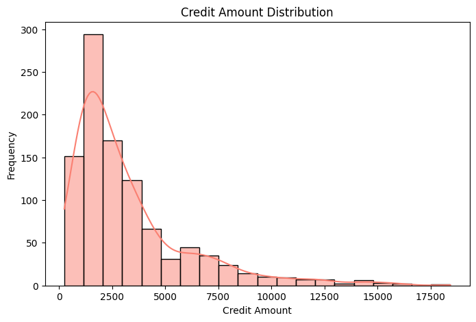

```python
plt.figure(figsize=(8,5))
sns.histplot(German_Credit['Credit amount'], bins=20, kde=True, color='salmon')
plt.title('Credit Amount Distribution')
plt.xlabel('Credit Amount')
plt.ylabel('Frequency')
plt.show()
```

## The distribution is highly skewed to the right and it is depicted in the histogram. Low levels of loans < 5,000 DM, and only a few high loans. The tail appears to pattern off at around 18,000 DM, which would indicate the presence of extreme loans, which would impact on model predictions.

# **Credit Amount vs Duration Scatter**

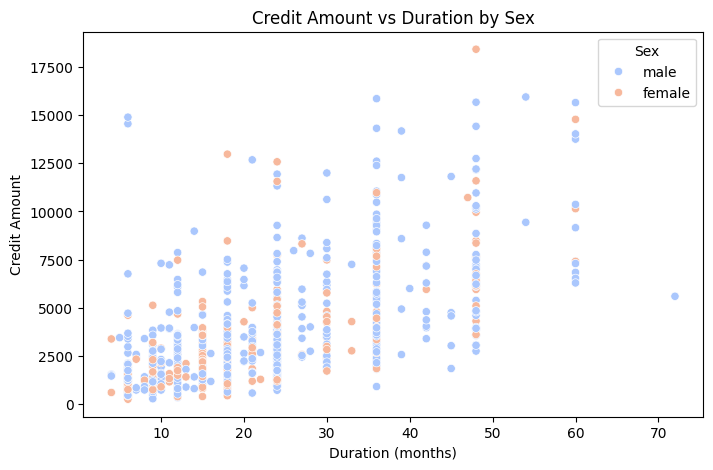

```python
plt.figure(figsize=(8,5))
sns.scatterplot(x='Duration', y='Credit amount', hue='Sex', data=German_Credit, palette='coolwarm')
plt.title('Credit Amount vs Duration by Sex')
plt.xlabel('Duration (months)')
plt.ylabel('Credit Amount')
plt.show()
```

## The value versus the length of its loan repayment has a positive inclination as indicated by the scatter graph. Demographics do not vary in any ways between men and women, and with longer term, the higher the sum of credit.

# **Count of Housing**

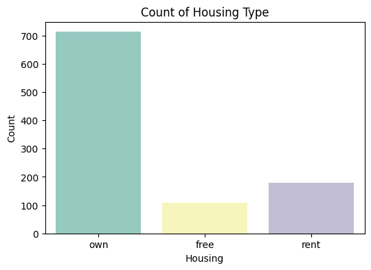

```python
plt.figure(figsize=(6,4))
sns.countplot(x='Housing', data=German_Credit, palette='Set3')
plt.title('Count of Housing Type')
plt.xlabel('Housing')
plt.ylabel('Count')
plt.show()
```

# **Count of Sex**

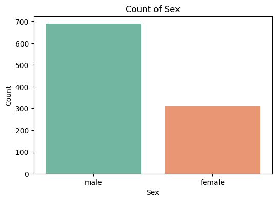

```python
plt.figure(figsize=(6,4))
sns.countplot(x='Sex', data=German_Credit, palette='Set2')
plt.title('Count of Sex')
plt.xlabel('Sex')
plt.ylabel('Count')
plt.show()
```

## According to the bar graph, it was evident that there was a disproportion of genders when it came to deciding on their application: two-thirds of the applicants were males, and one-third were females. This asymmetry is significant as far as the fairness of a machine learning model is concerned, since it might transfer such a bias without being tackled.

# **Encode categorical variables**

```python
categorical_cols = ['Sex', 'Housing', 'Saving accounts', 'Checking account', 'Purpose']
for col in categorical_cols:
    German_Credit[col] = LabelEncoder().fit_transform(German_Credit[col])
```

# **Define features and target**

```python
German_Credit['Target'] = (German_Credit['Credit amount'] > German_Credit['Credit amount'].median()).astype(int)
X = German_Credit.drop(columns=['Target', 'Credit amount'])
y = German_Credit['Target']
```

# **Split into train/test sets**

```python
X_train, X_test, y_train, y_test = train_test_split(X, y, test_size=0.3, random_state=42, stratify=y)
```

## This demonstrates how categorical variables (Sex, Housing, Saving accounts, Checking account, Purpose) have been encoded with the help of LabelEncoder, with a target binary Target being created based on the median credit amount. Finally, the dataset is split into a training (70 per cent) and a testing (30 per cent) set with the classes stratified, in order to test the model. This preconditions the construction of a data set that can be utilised to train the machine learning models appropriately and without any biases.

# **Train a baseline classifier**

```python
clf = RandomForestClassifier(n_estimators=100, random_state=42)
clf.fit(X_train, y_train)
```

```
RandomForestClassifier(random_state=42)
```

```python
y_pred = clf.predict(X_test)
```

# **Evaluate baseline model**

```python
print("Accuracy:", accuracy_score(y_test, y_pred))
print("Classification Report:\n", classification_report(y_test, y_pred))
```

```
Accuracy: 0.7433333333333333
Classification Report:
               precision    recall  f1-score   support

           0       0.74      0.76      0.75       150
           1       0.75      0.73      0.74       150

    accuracy                           0.74       300
   macro avg       0.74      0.74      0.74       300
weighted avg       0.74      0.74      0.74       300
```

## The baseline model accuracies (0.743) and classification reports are given in the figure. Classes are balanced on the basis of the precision and recall and F1-scores. It is on unseen data which the model is known to be robust. Before implementing bias mitigation, it is important to have an initial baseline since this can aid in the evaluation of the model after and after the bias implementation to show the improvement of the model and to see whether the credit decision being implemented is ethically sound.

# **Fairness Evaluation using 'Sex' as sensitive feature**

```python
sensitive_feature = X_test['Sex']
metric_frame = MetricFrame(
    metrics={'accuracy': accuracy_score},
    y_true=y_test,
    y_pred=y_pred,
    sensitive_features=sensitive_feature
)
```

```python
print("Accuracy by Sex:\n", metric_frame.by_group)
dp_diff = demographic_parity_difference(y_test, y_pred, sensitive_features=sensitive_feature)
eo_diff = equalized_odds_difference(y_test, y_pred, sensitive_features=sensitive_feature)
print("Demographic Parity Difference:", dp_diff)
print("Equalized Odds Difference:", eo_diff)
```

```
Accuracy by Sex:
      accuracy
Sex
0    0.742268
1    0.743842
Demographic Parity Difference: 0.05916408511502724
Equalized Odds Difference: 0.04473244147157196
```

## Much encouragement exists to conduct this type of analysis as far as a determination of fairness can aid in ensuring that the model is not biased or discriminatory towards applicants due to gender. This can aid in identifying that there is a risk of systematic discrimination and in anticipating other bias reduction interventions. The differences between the grounded fairness metrics are compared in the model assessment, allowing the straightforward application of fairness-aware algorithms to this model and adhering to ethical principles in AI application and GDPR principles (Kheya et al., 2024). In this manner that are fair and practical in making predictions of credit risks.

# **Bias Mitigation using Fairlearn**

```python
mitigator = ExponentiatedGradient(
    estimator=RandomForestClassifier(n_estimators=100, random_state=42),
    constraints=DemographicParity()
)
mitigator.fit(X_train, y_train, sensitive_features=X_train['Sex'])
```

```
ExponentiatedGradient(constraints=<fairlearn.reductions._moments.utility_parity.DemographicParity object at 0x7cfe85057830>,
                      estimator=RandomForestClassifier(random_state=42),
                      nu=np.float64(0.0014255025282953427))
```

```python
y_pred_mitigated = mitigator.predict(X_test)
```

## This value indicates the model-trained baseline random forest has been trained with an example of bias mitigation with the Exponentiated Gradient algorithm of Fairlearn. This is constrained by the so-called Demographic Parity that is meant to achieve similar improvement in the prediction rate among the sexes (under the assumption that it is sex that is the sensitive feature). Equal training data (Xtrain, ytrain) with fairness is used to fit the model with adjustments that are also added in the fitting. The test set (y_pred_mitigated) is avoided and predictions are made on the test set which is then assessed.

## In addition to that the significance of such a strategy is that it is the replication of gender bias recognised in the base model and therefore has the ability to provide the applicants with a just opportunity, besides achieving an acceptable predictive accuracy. The Exponentiated Gradient algorithm works in a methodology, one tunes the classifier in an iterative process such that a certain level of accuracy is maintained to satisfy the demographic parity requirements (Almutairi, et al., 2024). This is one of the mitigations necessary in regard to societal and ethical application of artificial intelligence, particularly the use of artificial intelligence in financial operations where lending is discriminatory and not acceptable.

# **Evaluate Mitigated Model**

```python
print("Accuracy after mitigation:", accuracy_score(y_test, y_pred_mitigated))
metric_frame_mitigated = MetricFrame(
    metrics={'accuracy': accuracy_score},
    y_true=y_test,
    y_pred=y_pred_mitigated,
    sensitive_features=sensitive_feature
)
```

```
Accuracy after mitigation: 0.7133333333333334
```

```python
print("Accuracy by Sex after mitigation:\n", metric_frame_mitigated.by_group)
dp_diff_mitigated = demographic_parity_difference(y_test, y_pred_mitigated, sensitive_features=sensitive_feature)
eo_diff_mitigated = equalized_odds_difference(y_test, y_pred_mitigated, sensitive_features=sensitive_feature)
print("Demographic Parity Difference after mitigation:", dp_diff_mitigated)
print("Equalized Odds Difference after mitigation:", eo_diff_mitigated)
```

```
Accuracy by Sex after mitigation:
      accuracy
Sex
0    0.639175
1    0.748768
Demographic Parity Difference after mitigation: 0.020212279721700255
Equalized Odds Difference after mitigation: 0.13844325609031494
```

# **Visualize Model Performance Comparison**

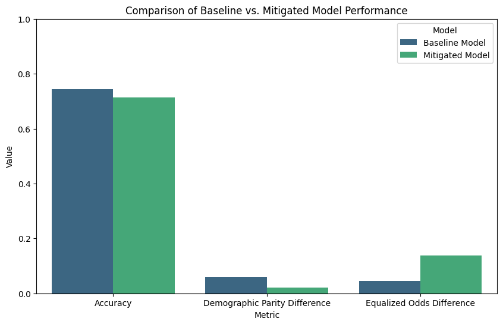

```python
metrics_data = {
    'Metric': ['Accuracy', 'Demographic Parity Difference', 'Equalized Odds Difference'],
    'Baseline Model': [accuracy_score(y_test, y_pred), dp_diff, eo_diff],
    'Mitigated Model': [accuracy_score(y_test, y_pred_mitigated), dp_diff_mitigated, eo_diff_mitigated]
}
metrics_df = pd.DataFrame(metrics_data)

metrics_df_melted = metrics_df.melt(id_vars='Metric', var_name='Model', value_name='Value')

plt.figure(figsize=(10, 6))
sns.barplot(x='Metric', y='Value', hue='Model', data=metrics_df_melted, palette='viridis')
plt.title('Comparison of Baseline vs. Mitigated Model Performance')
plt.ylabel('Value')
plt.ylim(0, 1) # Metrics are typically between 0 and 1
plt.show()
```